# Data preparation report

PreSA (2020-2023) and PostSA (2023)

Summary

This report details the data preparation workflow of the project. In order to ensure end-to-end reproducibility in our data management workflow, the code included in this report is used to operate directly on the raw data downloaded from Qualtrics™.

# Data files

The raw data files are downloaded from *Qualtrics™* into a folder called `data_raw` with their default *Qualtrics™* names, which includes the survey name plus the date and time of the download. The data is exported from *Qualtrics™* as SPSS `.sav` data files with the extra long labels option.

The *Qualtrics™* questionnaire was based on a design codeplan saved in an Excel `.xlsx` file, which is stored in a folder named `study_design`. The same folder also contains a spreadsheet with details about the survey participants who also participated in the follow-up qualitative interview phase of the data collection.

The `data_raw` and `study_design` folders contain the following files:

| path | size | modified |
| --- | --- | --- |
| data_raw/postSA_Focal_2023_3+February+2024_21.40.sav | 7.29M | 2024-02-03 21:41:12 |
| data_raw/preSA_Focal_2023_12+April+2024_12.08.sav | 23.44M | 2024-04-12 12:08:56 |
| data_raw/Study Abroad Expectations_September 11, 2023_17.06.sav | 43.24M | 2023-09-12 00:09:39 |
| data_raw/Study+Abroad+Expectations+–+External_September+11,+2023_17.09.sav | 23.82M | 2023-09-12 00:09:19 |
| study_design/MAXOUT-SA_Codeplan.xlsx | 55.82K | 2024-04-18 16:43:18 |
| study_design/MAXOUT-SA_Interviewees.xlsx | 12.83K | 2024-04-25 13:21:27 |
| study_design/postSA_survey_labels.csv | 11.85K | 2026-07-12 07:40:03 |
| study_design/preSA_survey_labels.csv | 20.86K | 2026-07-12 07:40:03 |

Printed on 12 July 2026

The code below sets up functional links to these files in **R**:

```r
#### File paths ----------------------------------------------------------------------------------

(datafiles    <- list.files("data_raw", pattern = "\\.sav"))          # List `.sav` files
(designfiles  <- list.files("study_design", pattern = "\\.xlsx"))     # List `.xlsx` files

## 2020 pre-SA
preSA20_focal_path   <- file.path("data_raw", grep("Study Abroad Expectations", datafiles, value = TRUE))     # 2020 focal-institution student data
preSA20_ext_path   <- file.path("data_raw", grep("External", datafiles, value = TRUE))                      # 2020 external (non-focal) student data

## 2023 pre-SA
preSA23_focal_path   <- file.path("data_raw", grep("preSA_Focal_2023", datafiles, value = TRUE))                # 2023 focal-institution pre-SA data

## 2023 post-SA
postSA23_focal_path  <- file.path("data_raw", grep("postSA_Focal_2023", datafiles, value = TRUE))               # 2023 focal-institution post-SA data

## Design
codeplan_path      <- file.path("study_design", grep("Codeplan", designfiles, value = TRUE))                # Excel survey codebook
interviewees_path  <- file.path("study_design", grep("Interviewees", designfiles, value = TRUE))            # Excel list of interviewees
```

# Pre-SA datasets

## Questionnaire/variable differences

The 2020 pilot data collection consists of a focal-institution and an external dataset. The difference between the two questionnaires was a single item that asked focal-institution respondents whether they would also be interested in participating in a qualitative interview study. Qualitative data was not collected from external respondents:

```
In focal institution but not in External data:
[1] "focal_interview"
[1] "Accept to participate in an interview"

The position of the variable in the dataset is:
[1] 303
```

The 2023 pre-SA survey had several differences compared to the 2020 questionnaire:

2020

2023

In which academic year do you expect to go on a Study Abroad year? [`sayr`]

- 2020/2021
- 2021/2022
- 2022/2023
- 2023/2024

In which year do you expect to go on a Study Abroad year/semester? [`sayr_23`]

- 2nd year
- 3rd year

Who do you expect to socialize with most while on Study Abroad? [`expect_socialise`]

1. “Mainly with people/colleagues from JP/KO”
2. “Mainly with friends/colleagues from my UK university”
3. “Mainly with other foreign students”
4. “Mainly with students from English speaking countries”
5. “I don’t know”

Who do you expect to socialize with most while on Study Abroad? [`expect_socialise_23`]

1. “Mainly with people/colleagues from JP/KO”
2. “Mainly with friends/colleagues from my UK university”
3. “Mainly with foreign students from the UK”
4. “Mainly with foreign students from other English speaking countries”
5. “Mainly with foreign students from non-English-speaking countries”
6. “I don’t know”

Block of 16 questions on “imagined self” was not asked

The `email` question asked for “university email address” specifically

The `sayr` and `expect_socialise` variables from 2023 were given the `_23` suffix to their variable names (in the Codeplan document).

## Data import

The code below imports into **R** the **pre-SA** data (`.sav` files), the variable information (names, labels) from the codeplan document (`survey_design/SA_codeplan.xlsx`), and information about which respondents also participated in qualitative follow-up interviews (`data_qualitative/MAXOUT-SA-Interviewees.xlsx`):

```r
#### Import from raw ----------------------------------------------------------------------------------------

## Pre-SA Codeplan
codeplan_pre <- read_excel(codeplan_path, sheet = "preSAvars")

## Interviewees
interviewees <- read_excel(interviewees_path) |> data_select(c("Random_ID", "interviewed_preSA", "interviewed_postSA"))

## 2020 pre-SA (focal institution)
preSA20_focal <- read_spss(preSA20_focal_path)                                          # Import from spss
names(preSA20_focal) <- codeplan_pre$varname_pre20                                    # Assign variable names
sjlabelled::set_label(preSA20_focal) <- codeplan_pre$varlabel_pre20                   # Assign variable labels

## 2020 pre-SA External
preSA20_ext <- read_spss(preSA20_ext_path)
names(preSA20_ext) <- codeplan_pre$varname_pre20[-303]                              # Assign variable names removing focal-institution-specific var
sjlabelled::set_label(preSA20_ext) <- codeplan_pre$varlabel_pre20[-303]             # Assign variable labels removing focal-institution-specific var

## 2023 pre-SA (focal institution)
preSA23_focal <- read_spss(preSA23_focal_path)
names(preSA23_focal) <- na.omit(codeplan_pre$varname_pre23)                           # Assign variable names
sjlabelled::set_label(preSA23_focal) <- na.omit(codeplan_pre$varlabel_pre23)          # Assign variable labels
```

## Data management variables

Before merging the datasets, we create an additional `cohort` column which records the academic year of the pre-SA data collection. The survey for the focal-institution study had been kept open for several months, spanning the second semester of the 2019/2020 academic year and the first semester of the 2020/2021 AY, and therefore the `preSA20_focal` dataset contains responses from two student cohorts (2019/2020 and 2020/2021). Data for the `preSA20_ext` dataset should only contain responses from the 2019/2020 student cohort due to the outbreak of the Covid-19 pandemic, which interfered with the data collection since international travel - and Study Abroad years - were put on hold. However, there is one response that was submitted in March 2021. This response will be removed from the dataset:

```r
#### Create `cohort` column ------------------------------------------------------------------------------------

preSA20_focal <- preSA20_focal |>
  mutate(cohort = case_when(StartDate < as.POSIXct("2020-09-01") ~ "19/20",
                            StartDate >= as.POSIXct("2020-09-01") ~ "20/21"))

preSA20_ext <- preSA20_ext |>
  mutate(cohort = "19/20") |>
  dplyr::filter(StartDate < as.POSIXct("2020-09-01"))  # remove response dating "2021-03-20 16:11:51"

preSA23_focal <- preSA23_focal |>
  mutate(cohort = "23/24")
```

## Merging the pre-SA datasets

Merging the three datasets should therefore have `ncol(preSA20_focal) + 3` = 312 variables.

The code below merges the datasets and checks its dimensions:

```r
#### Merge all pre-SA datasets from 2020 and 2023 ---------------------------------------------------------------
preSA <- sjmisc::add_rows(preSA20_focal,   # `this`sjmisc::add_rows` keeps `label` attribute but not other non-relevant attributes
                          preSA20_ext,    ## `dplyr::bind_rows` removes the variable label attributes
                          preSA23_focal)    ## `datawizard::data_merge` keeps all SPSS-specific attributes (`display_width`, `format.spss`)

### Check dimensions of merged dataframe
dim(preSA)
```

```
[1] 243 312
```

```
Number of columns as expected: TRUE
```

## Replacing piped text

The *Qualtrics™* questionnaire included piped text for Japanese and Korean language students, and these appear with non-human-readable characters in the variable and value labels, so we replace these characters with the phrase “JP/KO”. For example, see the value label of the `A1_comjpko` variable before and after the replacement:

Speaks with JP/KO friends in JP/KO (A1_comjpko)

| Value | Label | N | Raw % | Valid % | Cum. % |
| --- | --- | --- | --- | --- | --- |
| 1 | ${lm://Field/1} | 38 | 15.64 | 100 | 100 |

Speaks with JP/KO friends in JP/KO (A1_comjpko)

| Value | Label | N | Raw % | Valid % | Cum. % |
| --- | --- | --- | --- | --- | --- |
| 1 | JP/KO | 38 | 15.64 | 100 | 100 |

The code below makes the replacements across all the value labels in the dataset:

```r
#### Replace shortcodes for "Japanese" and "Korean" -----------------------------------------------------

## Get all value labels as list
labs <- sjlabelled::get_labels(preSA)

## Change all the values labels in all the variables in list
labs <- lapply(labs, function(x) str_replace_all(x,
                                                 '\\$[^\\}]*\\}',
                                                 "JP/KO"))

## Apply changed labels to dataset; keep labels as attribute (don't do `as_label(as.numeric)` beforehand)
preSA <- sjlabelled::set_labels(preSA, labels = labs, force.labels = TRUE)
```

## Converting categorical variables

We convert the values of all labelled factor (categorical) variables to their labels, so that later we can manipulate the values directly as text.

```r
#### Convert labelled factor variables ------------------------------

## This keeps the unused labels as well
preSA <- preSA |>
    mutate(across(where(is.factor), sjlabelled::as_numeric),
           across(everything(), sjlabelled::as_label))


## This keeps only the labels of categories that had valid responses
# preSA_alt <- preSA |>
#     mutate(across(where(is.factor), labels_to_levels))
```

## Combining Japanese and Korean versions of variables

The survey questions were broken down by language studied (Japanese/Korean), and we have duplicate variables coding the same question (prefixed with “A1_” for Japanese and “A2_” for Korean). With the code below we combine these variables:

```r
#### Unify variables split by language ---------------------------------------------------------

korean <- preSA |>
  dplyr::filter(language == "Korean") |>
  select(!starts_with("A1")) |>
  rename_with(stringr::str_replace,
              pattern = "A2_", replacement = "",
              matches("A2_"))

japanese <- preSA |>
  dplyr::filter(language == "Japanese") |>
  select(!starts_with("A2")) |>
  rename_with(stringr::str_replace,
              pattern = "A1_", replacement = "",
              matches("A1_"))

missing <- preSA |>
  dplyr::filter(is.na(language)) |>                   # 13 missing answers to language
  datawizard::remove_empty_columns()                  # remove all empty columns

preSA <- sjmisc::add_rows(japanese, korean, missing)
```

## Removing incomplete responses

There were 13 responses with missing data on language. Since the language studied was a core compulsory-answer item, these 13 cases were also unfinished responses. Of the 243 responses in the pre-SA dataset 183 have been finished and submitted. We keep only finished cases:

```r
#### Keep only completed and submitted responses ---------------------------

preSA <- preSA |>
  dplyr::filter(Finished == "True")
```

## Removing duplicates

E-mail addresses were requested primarily for the purposes of contacting students who opted in for participation in a follow-up qualitative interview and/or future (post-SA) rounds of data collection, as well as for contacting the winner of the randomly selected participation prize. Respondent e-mail addresses and IP Addresses are also helpful for identifying any data reliability issues, such as duplicate responses (n.b. the IPAddress collected by *Qualtrics™* is “external”, so those connecting to the same network will share an IP; for this reason, selecting on IP Address is not useful here).

We find four email addresses with duplicate responses:

| No. of duplicate emails | ID_first | ID_second |
| --- | --- | --- |
| 2 | 9419 | 8436 |
| 2 | 9514 | 8175 |
| 2 | 95339 | 70145 |
| 2 | 84953 | 44422 |

```r
#### Will delete the later responses (incidentally, these also have fewer NAs) -----------------
`%not_in%` = Negate(`%in%`)

preSA <- preSA |>
  data_filter(Random_ID %not_in% c("8436", "8175", "70145", "44422"))    # keeps original "rownames"; `rownames(preSA) <- NULL` to renumber
```

This leaves us with 179 responses/cases/rows.

We can also check whether any Random_ID numbers have been allocated multiple times (unfortunately, *Qualtrics™* doesn’t have a system to fine-tune the randomisation of numbers…). We find that the `Random_ID` number `3591` has been allocated twice:

| Random_ID | cohort | uni | language |
| --- | --- | --- | --- |
| 3591 | 20/21 | Focal institution | Japanese |
| 3591 | 19/20 | Cardiff University | Japanese |

One was allocated to an external participant, so we replace it by adding a suffix consisting of two `0`s to it:

```r
#### Fix identical Random_IDs -------------------------------------------------------------
preSA$Random_ID[preSA$uni == "Cardiff University" & preSA$Random_ID == "3591" ] <- "359100"
```

## Variable selection

### Select out sensitive data

We can select out variables that contain more sensitive information to store separately from the main analysis dataset:

```r
### Select out meta- and safeguarded variables ---------------------------------------------

preSA_sensitive <- preSA |>
  select(Status:Progress, Finished:UserLanguage, postcode, followup, focal_interview, email, Random_ID)
```

### Select out textual data

We can also select out variables that contain text entered in open-ended survey questions. These were identified with the `_txt` suffix in the Codeplan. We create and select the most useful variables to keep in the textual dataset:

```r
### Get names of textual variables -----------------------------------------------------------------------------------------------

text_variables <- str_subset(names(preSA), pattern = "_txt")

### Select and create variables to keep in the textual dataset -------------------------------------------------------------------

preSA_textual <- preSA |>
  # create text variable concatenating all school types attended
  data_unite(select = contains("school_"), new_column = "schools_combined", remove_na = TRUE, append = TRUE, separator = ", ") |>
  # data_unite() doesn't want to exclude NAs... bug in the code... have to remove manually...
  data_modify(.at = "schools_combined", .modify = function(x) {text_remove(x, ", NA")}) |>
  data_modify(.at = "schools_combined", .modify = function(x) {text_remove(x, "NA, ")}) |>
  # select variables to keep
  data_select(c(Random_ID, uni, cohort, language, sayr, sayr_23,
                gender, age, intstudnt, bornuk, pargrad, schools_combined,
                text_variables))
```

### Recode textual data

It is more useful to keep a numeric version of the textual variables, which records the number of words in the answers provided, rather than the answers themselves. To distinguish between these and the original variables, we add the suffix `_nwords` to their names:

```r
### Function to count all "word" characters, first converting empty strings to NA
wordcounts <- function(x) {
  label <- get_label(x)               # save var labels
  x |> convert_to_na(na = "") |>      # convert to NA to avoid 0 values
       str_count('\\w+') |>           # count all "words"
  set_label(label)                    # reassign the saved labels
  }

#### Recode textual variables to wordcount numeric variables; add suffix to var name -----
preSA <- preSA |>
         data_modify(.at = text_variables, .modify = wordcounts) |>
         data_addsuffix(pattern = "_nwords", select = text_variables)
```

### Remove, add, relocate and label variables

Final variable preparation tasks. We exclude the sensitive data from the dataset, as well as the PIS variable and topic header variables; we add a variable counting the number of missing answers for each respondent; we add two additional variables recording whether the respondent has also participated in a qualitative in-depth interview at the pre-SA and post-SA stage; we reorder and label variables:

```r
### Remove, add and relocate variables ---------------------------------------------------------

# Add variable on interviewees
preSA <- data_merge(preSA, interviewees, id = "Random_ID")
preSA_textual <- data_merge(preSA_textual, interviewees, id = "Random_ID")

preSA <- preSA |>
  # remove variables
  select(!c(StartDate, EndDate, Status, IPAddress, Progress, RecordedDate:UserLanguage,
            postcode, email, followup, focal_interview,
            Finished, pis,
            contains("Topics"))) |>
  # add of count missing answers
  rowwise() |>
    mutate(missing_answers = sum(is.na(across(everything())))) |>
  ungroup() |>
  # relocate
  relocate(c(Random_ID, Duration, missing_answers, interviewed_preSA, interviewed_postSA, uni, cohort)) |>
  relocate(sayr_23, .after = sayr) |>
  relocate(expect_socialise_23, .after = expect_socialise)


# attr(preSA2023$missing_answers, "label") <- "Number of unanswered items"

preSA <- preSA |> var_labels(missing_answers = "Number of unanswered items",
                                     interviewed_preSA = "Interviewed before Study Abroad",
                                     interviewed_postSA = "Re-interviewed after Study Abroad",
                                     cohort = "Student cohort")
```

### Analysis dataset check

The final analysis dataset contains 179 responses and 172 variables. 143 responses are from focal-institution students. There are 2 variables containing only `NA` values: proglength_txt_nwords, sib4occ_study_txt_nwords. The minimum number of missing answers across the dataset is 26 and the maximum is 62, with a median of 40:

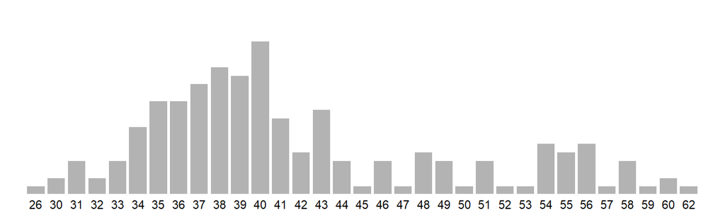

# Post-SA dataset

The aim of the post-SA data collection was to provide a sense of how opinions have changed following the Study Abroad year. Many survey questions have been repeated (almost) as they were first asked in the pre-SA data collection, and a more limited number of new items were also introduced. Variables that have an equivalence with the pre-SA data have received the same name stub as in the pre-SA dataset, followed by the **_post** suffix. New variables without an equivalent in the pre-SA dataset have received the **post_** prefix. A number of variables that were programmatically included in the *Qualtrics™* survey have the same name as in the pre-SA dataset and will be excluded or modified, keeping only the shared variables needed for matching and merging the responses from the same individuals.

## Data import

The code below imports the **post-SA** data (`.sav` files) and the variable information (names, labels) from the Codeplan spreadsheet (`survey_design/SA_codeplan.xlsx`) into **R**:

```r
#### Import from raw -----------------------------------------------------------------------------------

## Post-SA codeplan
codeplan_post <- read_excel(codeplan_path, sheet = "postSAvars")

## 2023 post-SA (focal institution)
postSA23_focal <- read_spss(postSA23_focal_path)
names(postSA23_focal) <- na.omit(codeplan_post$varname_post23)                    # Assign variable names
sjlabelled::set_label(postSA23_focal) <- na.omit(codeplan_post$varlabel_post23)   # Assign variable labels
```

The raw `postSA23_focal` dataset has 34 answers and 117 variables.

## Data cleansing

We fix *Qualtrics™* shortcodes in labels and convert categorical variable types. We keep the 32 completed responses only. We also remove several variables that were reused/pre-filled automatically from the pre-SA survey, keeping only the pre-filled `Random_ID` variable for merging. One of the pre-filled `Random_ID`s corresponds to one of the duplicates that were deleted from the pre-SA dataset. We replace this ID with that of the case kept in the analysis for the purpose of merging. We remove sensitive data.

```r
#### Replace shortcodes for "Japanese" and "Korean" -----------------------------------------------------------

labs <- sjlabelled::get_labels(postSA23_focal)
labs <- lapply(labs, function(x) str_replace_all(x,
                               '\\$[^\\}]*\\}',
                               "JP/KO"))

postSA23_focal <- postSA23_focal |>
  sjlabelled::set_labels(labels = labs, force.labels = TRUE)
```

```r
#### Extract sensitive data ------------------------------------------------------------------------------------
postSA_sensitive <- postSA23_focal |>
  dplyr::select(c(post_qual_1, post_qual_2,                                          # PIS and eligibility vars
                  post_email_uni, post_aftergrad_followup, post_email_personal,      # Sensitive
                  Random_ID))


#### Select cases and variables --------------------------------------------------------------------------------
postSA <- postSA23_focal |>
  ## Convert labelled factor variables
  mutate(across(where(is.factor), sjlabelled::as_numeric),
         across(everything(), sjlabelled::as_label)) |>
  ## Select valid responses
  dplyr::filter(Finished_post == "True" &
                post_qual_1 == "I agree to take part" &
                post_qual_2 == "I have done a full year of study abroad") |>
  ## Select useful variables
  dplyr::select(!c(StartDate_post:Progress_post, Finished_post:UserLanguage_post,    # Qualtrics variables
                  uni_post, pre_course, course:SAcountry,                            # Prefilled from Pre-SA survey
                  post_qual_1, post_qual_2,                                          # PIS and eligibility vars
                  post_email_uni, post_aftergrad_followup, post_email_personal)) |>  # Sensitive
  ## add of count missing answers
  rowwise() |>
    mutate(missing_answers_post = sum(is.na(across(everything())))) |>
  ungroup() |>
  ## move to the top
  data_relocate(c(Random_ID, missing_answers_post)) |>
  ## add label to new variable
  var_labels(missing_answers_post = "Number of unanswered items")

#### Replace a `Random_ID`
postSA$Random_ID[postSA$Random_ID == "8436" ] <- "9419"
```

### Select out and recode textual data

In the postSA dataset variables that contain textual data entered in open-ended survey questions are identified in two ways: for variables unique to the post-SA survey - which carry the **post_** prefix - they are suffixed with **_txt**, whereas for variables repeated across the two surveys the whole suffix is **_txt_post**. There are 11 such variables.

```r
### Get names of textual variables -----------------------------------------------------------------------------------------------

text_variables_post <- str_subset(names(postSA), pattern = "_txt")

### Select and create variables to keep in the textual dataset -------------------------------------------------------------------

postSA_textual <- postSA |>
  data_select(c(Random_ID, post_course_same, post_SAuni_satisfaction,
                text_variables_post))
```

It is more useful to keep a numeric version of the textual variables, which records the number of words in the answers provided, rather than the answers themselves. To distinguish between these and the original variables, we add the suffix `_nwords` to their names:

```r
#### Recode textual variables to wordcount numeric variables; add suffix to var name -----
#### use the same `wordcounts()` function defined above
postSA <- postSA |>
          data_modify(.at = text_variables_post, .modify = wordcounts) |>
          data_addsuffix(pattern = "_nwords", select = text_variables_post)
```

## Merging pre-SA and post-SA data

We merge the`postSA23_focal` dataset with the responses from the same individuals from the `preSA` dataset:

```r
postSA <- data_merge(preSA, postSA, join = "inner", by = "Random_ID")
```

We also merge the textual datasets:

```r
SA_textual <- data_merge(preSA_textual, postSA_textual, join = , by = "Random_ID")
```

# Export datasets

We export the analysis datasets with the names `preSA2023` and `postSA2023` to SPSS `.sav` format to a new folder called `data_in`. We export the sensitive data to another folder called `data_lock`. We also export the textual data to an Excel sheet and include variable names, labels and their concatenated version as additional rows to make them more informative as column headers in Excel:

```r
## Export main datasets ---------------------------------------------------------------------------------

fs::dir_create("data_in")
sjlabelled::write_spss(preSA, "data_in/preSA2023.sav")
sjlabelled::write_spss(postSA, "data_in/postSA2023.sav")

fs::dir_create("data_lock")
sjlabelled::write_spss(preSA_sensitive, "data_lock/preSA2023_sensitive.sav")
sjlabelled::write_spss(postSA_sensitive, "data_lock/postSA2023_sensitive.sav")

## Export qualitative dataset ----------------------------------------------------------------------

# For this we use a function I wrote that modifies the behaviour of datawizard::data_write() to allow variable labels to be saved as
# the first row in the exported text file. This is achieved with an additional optional setting `labels_to_row = TRUE`.
# If `labels_to_row` is not specified, the function does the same as datawizard::data_write()

# Import the function: use the local copy when offline, otherwise fetch it from the GitHub Gist

if (file.exists("my_data_write.R")) {
  source("my_data_write.R")
} else {
  devtools::source_gist("https://gist.github.com/CGMoreh/a706954fb56cf8cc4a1ddc53ac1a4737", filename = "my_data_write.R")
}

data_write(SA_textual, "data_in/SA_textual.xlsx", labels_to_row = TRUE)
```

# Copy data files to shared folders

Finally, we copy over the non-sensitive analysis datasets to a folder shared by the research team. These datasets can for the basis of replication datasets which can be made publicly available on data repositories to supplement publications from the project. The analysis datasets also contain textual responses to open-ended survey questions, which should also be removed from any public datasets, or reviewed for sensitive information before making it publicly available.

```r
fs::dir_copy("data_in", path(shared_path, "data_in"), overwrite = TRUE)
fs::dir_copy("study_design", path(shared_path, "study_design"), overwrite = TRUE)

fortab <- fs::dir_info(c(fs::path(shared_path, "data_in"),
               fs::path(shared_path, "study_design")),
             )[, c(1,3,5)] |>
  dplyr::rename(modified = modification_time) |>
  # anonymise the shared-folder prefix in the printed table
  dplyr::mutate(path = stringr::str_replace(path, stringr::fixed(shared_path), "[shared project folder]"))
tinytable::tt(fortab, notes = paste("Printed on", format(Sys.Date(), "%d %B %Y"))) |>
  style_tt(i=0:nrow(fortab),
           fontsize = 0.8,
           bootstrap_css = "padding-right: 20px; padding-left: 0; padding-top: 0; padding-bottom: 0;"
       ) |>
  style_tt(nrow(fortab)+1,
           bold = TRUE,
           line = "t",
           line_color = "lightgray",
           fontsize = 0.8,
           bootstrap_css = "padding-right: 20px; padding-left: 0; padding-top: 0; padding-bottom: 0;"
       )
```

| path | size | modified |
| --- | --- | --- |
| [shared project folder]/data_in/postSA2023.sav | 119.6K | 2026-07-12 07:46:42 |
| [shared project folder]/data_in/preSA2023.sav | 275.1K | 2026-07-12 07:46:42 |
| [shared project folder]/data_in/preSA2023_textual.xlsx | 96.4K | 2024-05-09 21:46:00 |
| [shared project folder]/data_in/SA_textual.xlsx | 106.6K | 2026-07-12 07:46:43 |
| [shared project folder]/study_design/MAXOUT-SA_Codeplan.xlsx | 55.8K | 2024-04-18 16:43:18 |
| [shared project folder]/study_design/MAXOUT-SA_Interviewees.xlsx | 12.8K | 2024-04-25 13:21:27 |
| [shared project folder]/study_design/postSA_survey_labels.csv | 11.8K | 2026-07-12 07:46:42 |
| [shared project folder]/study_design/preSA_survey_labels.csv | 20.9K | 2026-07-12 07:46:41 |

Printed on 12 July 2026